# Practicum 7: Descriptive Statistics

Data Science for Biomedical Informatics (BMIN503/EPID600)

New packages to install for this practicum:

```r
install.packages("datasets")
```

Functions related to obtaining summary statistics and performing data manipulation that help us perform exploratory analysis are covered below. As was the case in practicum 6, the operations we will cover are routinely used to become familiar with datasets and make decisions about how best to use data to answer questions of interest.

Several statistical analysis tools cannot handle missing data, and a common way to deal with this is to keep subsets of “complete” data. R has a built-in function to keep individual rows with no missing variables, `complete.cases()`.

```r
x <- c(1:3, NA, 5:7, NA)
y <- c(NA, letters[2:8])
z <- cbind(x, y)
z
```

```
##      x   y
## [1,] "1" NA
## [2,] "2" "b"
## [3,] "3" "c"
## [4,] NA  "d"
## [5,] "5" "e"
## [6,] "6" "f"
## [7,] "7" "g"
## [8,] NA  "h"
```

```r
complete.cases(z)
```

```
## [1] FALSE  TRUE  TRUE FALSE  TRUE  TRUE  TRUE FALSE
```

```r
z[complete.cases(z), ]
```

```
##      x   y
## [1,] "2" "b"
## [2,] "3" "c"
## [3,] "5" "e"
## [4,] "6" "f"
## [5,] "7" "g"
```

```r
#With our NHANES dataset
library(dplyr)
nhanes <- read.csv(url("https://raw.githubusercontent.com/HimesGroup/BMIN503/master/DataFiles/NHANES_2007to2008.csv"), header=TRUE)
complete.nhanes <- nhanes %>%
                        filter(complete.cases(.))
dim(nhanes)
```

```
## [1] 10149    12
```

```r
dim(complete.nhanes)
```

```
## [1] 1762   12
```

### Summary Statistics

Let’s clean the nhanes dataset before proceeding.

```r
nhanes <- nhanes %>%
            rename(id=SEQN, gender=RIAGENDR, age=RIDAGEYR, race=RIDRETH1, education=DMDEDUC2, income=INDHHIN2, health.provider=HUQ040, asthma=MCQ010) %>%
            mutate(gender=factor(gender, levels=c(1, 2), labels=c("male", "female"))) %>%
            mutate(race=factor(race, levels=c(3, 1, 2, 4, 5), labels=c("white", "MexicanAmerican", "Hispanic", "black", "other"))) %>%
            #Changing definition of asthma so that cases==1, controls==0, else NA
            mutate(asthma=ifelse(asthma %in% c(7,9), NA, ifelse(asthma==2, 0, 1)))
```

In addition to using this external dataset, we will use data that is part of the `datasets` package (see more using `library(help = "datasets")`). Specifically, we will use `airquality`, a sampling of New York Air Quality measurements from May-Sep 1973.

The most common descriptive statistics that are retrived for variables (e.g., mean, standard deviation, quantiles, median, standard error) have built-in R functions. While functions like `summary` provide several of these values, others can be retrieved individually or with help from `dplyr`.

```r
library(datasets)
str(airquality)
```

```
## 'data.frame':    153 obs. of  6 variables:
##  $ Ozone  : int  41 36 12 18 NA 28 23 19 8 NA ...
##  $ Solar.R: int  190 118 149 313 NA NA 299 99 19 194 ...
##  $ Wind   : num  7.4 8 12.6 11.5 14.3 14.9 8.6 13.8 20.1 8.6 ...
##  $ Temp   : int  67 72 74 62 56 66 65 59 61 69 ...
##  $ Month  : int  5 5 5 5 5 5 5 5 5 5 ...
##  $ Day    : int  1 2 3 4 5 6 7 8 9 10 ...
```

```r
mean(airquality$Ozone, na.rm=TRUE)
```

```
## [1] 42.12931
```

```r
sd(airquality$Ozone, na.rm=TRUE)
```

```
## [1] 32.98788
```

```r
quantile(airquality$Ozone, na.rm=TRUE)
```

```
##     0%    25%    50%    75%   100%
##   1.00  18.00  31.50  63.25 168.00
```

```r
summarise(airquality, ozone = mean(Ozone, na.rm=TRUE))
```

```
##      ozone
## 1 42.12931
```

```r
airquality %>%
    select(Ozone:Temp) %>%
    summarise_all(mean, na.rm=TRUE)
```

```
##      Ozone  Solar.R     Wind     Temp
## 1 42.12931 185.9315 9.957516 77.88235
```

```r
airquality %>%
    select(Ozone:Temp) %>%
    summarise_all(funs(mean(., na.rm=TRUE), sd(., na.rm=TRUE)))
```

```
##   Ozone_mean Solar.R_mean Wind_mean Temp_mean Ozone_sd Solar.R_sd  Wind_sd Temp_sd
## 1   42.12931     185.9315  9.957516  77.88235 32.98788   90.05842 3.523001 9.46527
```

### Relationships Among Variables

```r
airquality %>%
    group_by(Month) %>%
    summarise(ozone = mean(Ozone, na.rm=TRUE))
```

```
## # A tibble: 5 x 2
##   Month ozone
##   <int> <dbl>
## 1     5  23.6
## 2     6  29.4
## 3     7  59.1
## 4     8  60.0
## 5     9  31.4
```

```r
nhanes %>%
    group_by(asthma) %>%
    summarise(n())
```

```
## # A tibble: 3 x 2
##   asthma `n()`
##    <dbl> <int>
## 1      0  8274
## 2      1  1385
## 3     NA   490
```

```r
nhanes %>%
    group_by(asthma) %>%
    summarise(count = n()) %>%
    mutate(prop = count/sum(count))
```

```
## # A tibble: 3 x 3
##   asthma count   prop
##    <dbl> <int>  <dbl>
## 1      0  8274 0.815
## 2      1  1385 0.136
## 3     NA   490 0.0483
```

A few more examples of using dplyr to get summary data.

```r
nhanes %>%
    filter(income %in% c(1:10, 14, 15)) %>%
    mutate(income.short = cut(income, breaks=c(0, 5, 10, 15), labels=c("<$25K", "$25-75K", ">$75K"))) %>%
    count(gender, income.short)
```

```
## # A tibble: 6 x 3
##   gender income.short     n
##   <fct>  <fct>        <int>
## 1 male   <$25K         1506
## 2 male   $25-75K       2089
## 3 male   >$75K         1095
## 4 female <$25K         1644
## 5 female $25-75K       2012
## 6 female >$75K          965
```

```r
nhanes %>%
    filter(health.provider %in% c(1:5)) %>%
    group_by(health.provider) %>%
    summarize(age=mean(age, na.rm=TRUE))
```

```
## # A tibble: 5 x 2
##   health.provider   age
##             <int> <dbl>
## 1               1  29.6
## 2               2  33.7
## 3               3  34.3
## 4               4  38.9
## 5               5  38.9
```

### Basic Descriptive Plots

We will use `ggplot`, a general and customizable plotting function of the `ggplot2` package to create plots. There is a learning curve to become familiar with `ggplot` and its advanced capapbilities, but the time investment is worth it to create publication-ready graphics. The official [`ggplot2`](http://docs.ggplot2.org/current/) documentation provides an idea of how much this package can do. Today we will use it to create basic plots. In general, we first tell `ggplot` what data we are using, provide aesthetic mappings, and then tell it how to represent this data visually.

To get a sense of the distribution of a categorical variable, use **barcharts**.

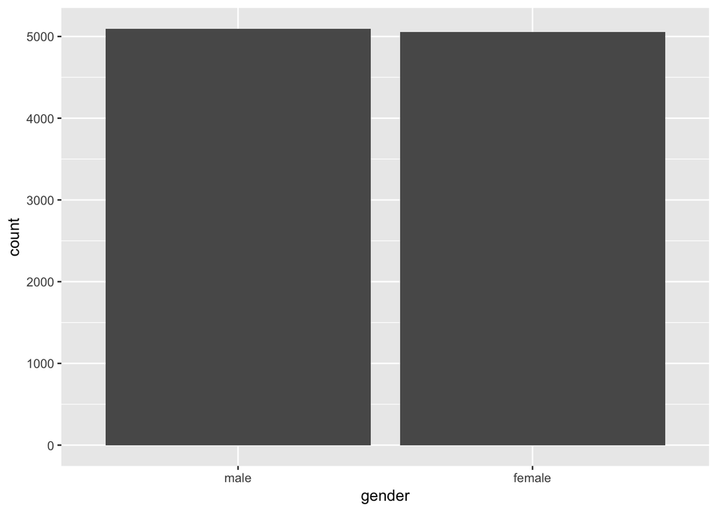

```r
library(ggplot2)
ggplot(data=nhanes, aes(x=gender)) + #Load data, specify variables
    geom_bar() #Add a visual layer that is a barplot
```

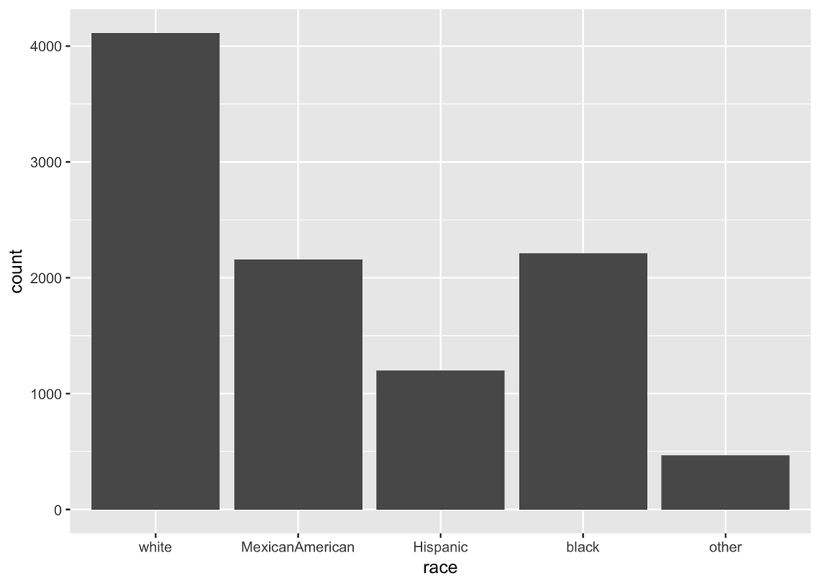

```r
ggplot(data=nhanes, aes(x=race)) +
    geom_bar()
```

To get a sense of the distribution of a continuous variable, use **histograms**.

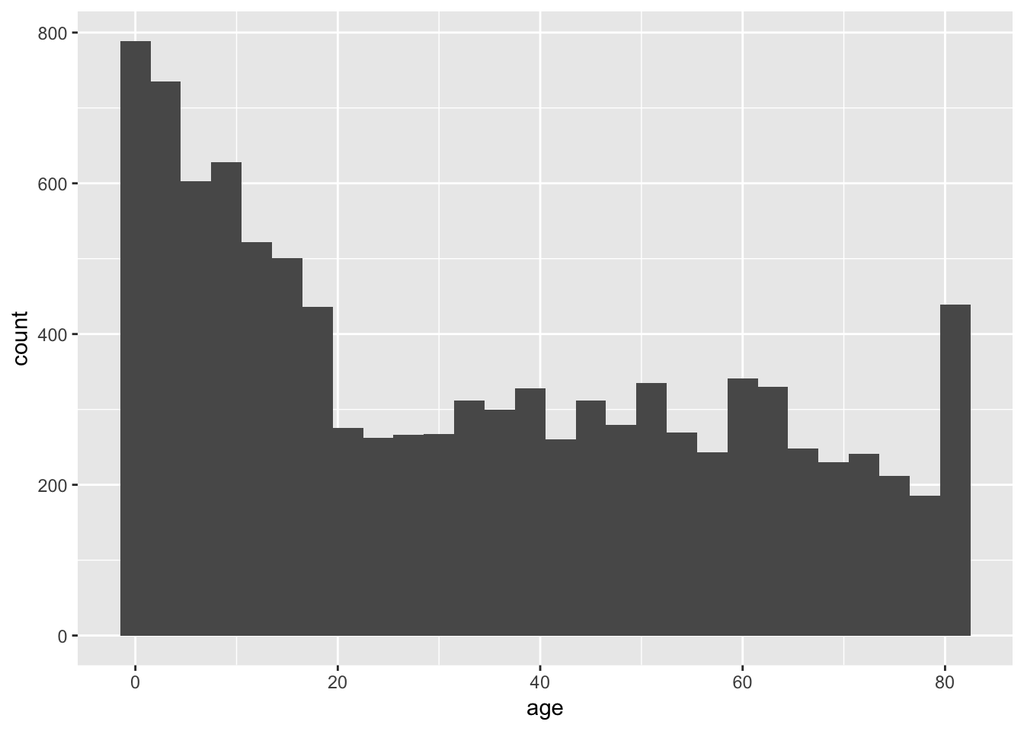

```r
ggplot(data=nhanes, aes(x=age)) +
    geom_histogram(binwidth = 3)
```

To look at how a binary/categorical variable changes by a binary/categorical variable, use **barplots** that are split by one of the variables.

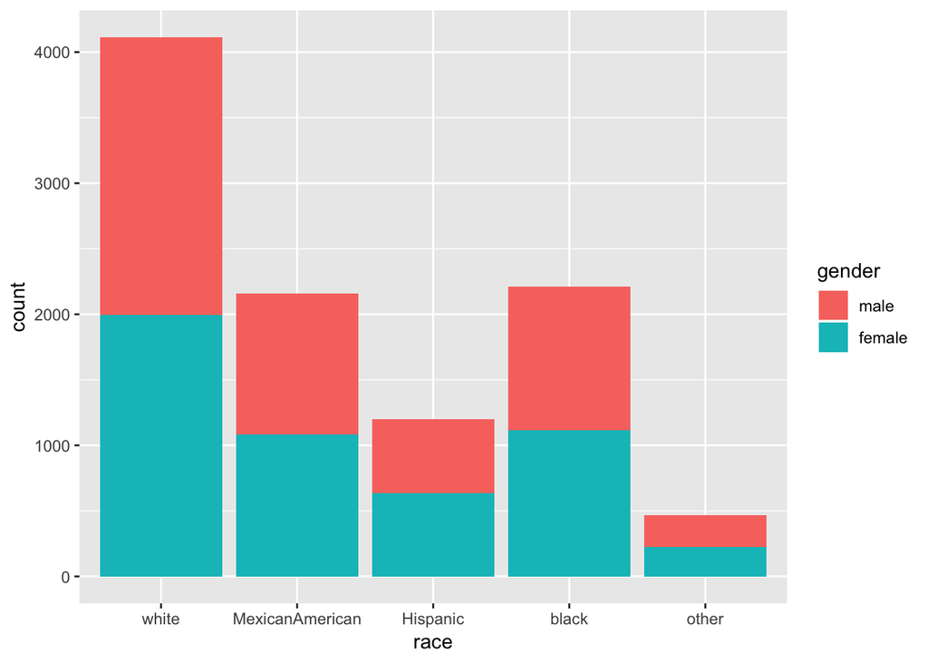

```r
ggplot(data=nhanes, aes(x=race, fill=gender)) +
    geom_bar()
```

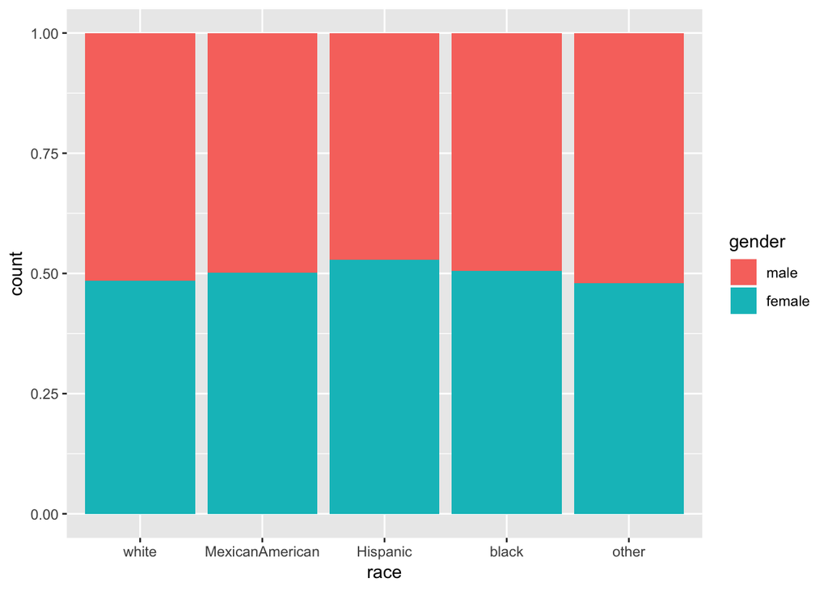

```r
#Proportions of each "fill" category within each x-axis category:
ggplot(data=nhanes, aes(x=race, fill=gender)) +
    geom_bar(position="fill")
```

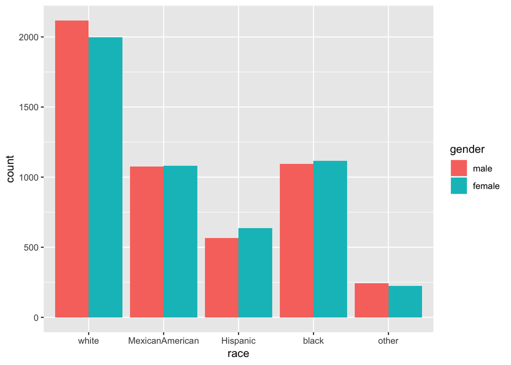

```r
#Counts for each "fill" category side-by-side for each x-axis category:
ggplot(data=nhanes, aes(x=race, fill=gender)) +
    geom_bar(position="dodge")
```

To look at how a continuous variable changes by a binary or categorical variable, use **boxplots**.

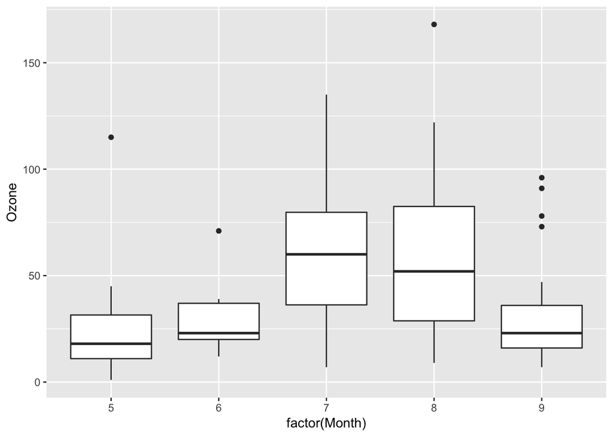

```r
ggplot(data=airquality, aes(x=factor(Month), y=Ozone)) +
    geom_boxplot()
```

To see how two continuous variables are related to each other, use a **scatterplots**.

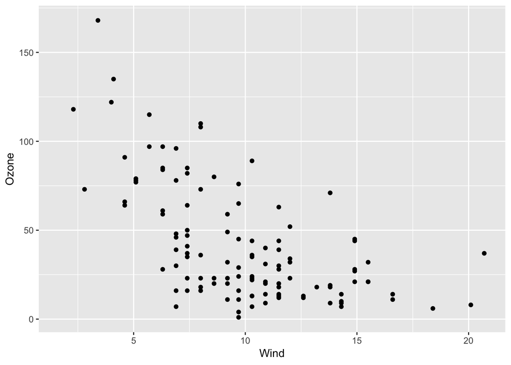

```r
ggplot(data=airquality, aes(x=Wind, y=Ozone)) +
    geom_point()
```

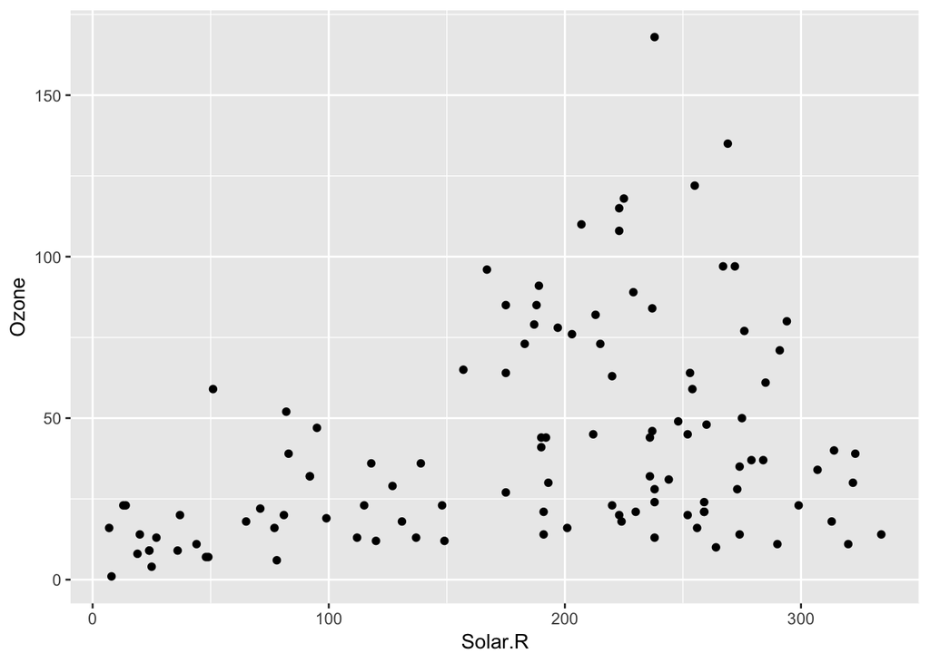

```r
ggplot(data=airquality, aes(x=Solar.R, y=Ozone)) +
    geom_point()
```